# ST5227 Tutorial 3

Yeo Ming Jie, Jonathan

## Question 1: Cubic Spline Regression

Suppose we regress $y$ on $x$ with the following nonparametric model

$$y = m(x) + \epsilon$$

To estimate $m(x)$, we approximate it by spline functions

$$m(x) = \beta_0 + \beta_1x + \beta_2x^2 + \beta_3x^3 + \beta_4(x-0.3)_+^3
+ \beta_5(x-0.5)_+^3 + \beta_6(x-0.7)_+^3$$

```r
# Loading data
xy <- read.table('dataT04a.dat')
y = xy[,1]; x = xy[,2]
x1 = x; x2 = x^2; x3 = x^3
x4 = (x-.3)^3*(x>0.3) # initialize positive parts in spline
x5 = (x-.5)^3*(x>0.5)
x6 = (x-.7)^3*(x>0.7)

fm <- lm(y ~ x1+x2+x3+x4+x5+x6)
summary(fm)
```

```
##
## Call:
## lm(formula = y ~ x1 + x2 + x3 + x4 + x5 + x6)
##
## Residuals:
##       Min        1Q    Median        3Q       Max
## -0.108094 -0.038900  0.002729  0.030799  0.139090
##
## Coefficients:
##             Estimate Std. Error t value Pr(>|t|)
## (Intercept)  1.01836    0.03484  29.226  < 2e-16 ***
## x1           1.07066    0.69146   1.548    0.125
## x2          -1.78715    3.61265  -0.495    0.622
## x3           1.76109    5.37774   0.327    0.744
## x4          -7.01417    9.12707  -0.769    0.444
## x5           4.39383    7.81053   0.563    0.575
## x6          42.46694    8.73792   4.860 4.75e-06 ***
## ---
## Signif. codes:  0 '***' 0.001 '**' 0.01 '*' 0.05 '.' 0.1 ' ' 1
##
## Residual standard error: 0.05194 on 93 degrees of freedom
## Multiple R-squared:  0.8673, Adjusted R-squared:  0.8587
## F-statistic: 101.3 on 6 and 93 DF,  p-value: < 2.2e-16
```

Estimated regression function is given by

$$\hat m(x) = 1.018359 + 1.070661x -1.787149x^2 + 1.761094x^3
-7.014172(x-0.3)_+^3 + 4.393831(x-0.5)_+^3 + 42.466937 (x-0.7)_+^3$$

The t-test indicates that `x4` aand `x5` are not statistically significant (with p-value $> 0.05$). Cubic terms $x, x^2$ and $x^3$ are retained by Hierarchy principle. We refit the model, and the simplified model is given by the following:

$$\hat m(x) = 1.037 + 0.565x + 1.042x^2 -2.508x^3 + 45.067(x-0.7)_+^3$$

```r
fm1 <- lm(y ~ x1+x2+x3+x6)
summary(fm1)
```

```
##
## Call:
## lm(formula = y ~ x1 + x2 + x3 + x6)
##
## Residuals:
##       Min        1Q    Median        3Q       Max
## -0.109887 -0.037979  0.001705  0.029370  0.139694
##
## Coefficients:
##             Estimate Std. Error t value Pr(>|t|)
## (Intercept)  1.03749    0.02365  43.872  < 2e-16 ***
## x1           0.56531    0.24835   2.276   0.0251 *
## x2           1.04248    0.67936   1.534   0.1282
## x3          -2.50750    0.52070  -4.816 5.53e-06 ***
## x6          45.06667    3.37869  13.339  < 2e-16 ***
## ---
## Signif. codes:  0 '***' 0.001 '**' 0.01 '*' 0.05 '.' 0.1 ' ' 1
##
## Residual standard error: 0.05157 on 95 degrees of freedom
## Multiple R-squared:  0.8663, Adjusted R-squared:  0.8607
## F-statistic: 153.9 on 4 and 95 DF,  p-value: < 2.2e-16
```

From the F-statistic (153.9) with corresponding p-value $< 2.2e-16$, we reject the null and conclude that the model is significant at level $0.05$.

Lastly, we compute the predictions (expected value) and corresponding $95\%$ confidence intervals for the following sequence of $x$ values:

```r
xnew = c(0, 0.1, 0.2, 0.3, 0.4, 0.5, 0.6, 0.7, 0.8, 0.9, 1)
x1new = xnew; x2new = xnew^2; x3new = xnew^3
x6new = (xnew-.7)^3*(xnew>0.7)
predict(fm1, list(x1 = x1new, x2 = x2new, x3 = x3new, x6 = x6new), interval='confidence')
```

```
##          fit       lwr       upr
## 1  1.0374863 0.9905391 1.0844334
## 2  1.1019347 1.0797611 1.1241084
## 3  1.1721877 1.1501373 1.1942382
## 4  1.2332003 1.2124278 1.2539727
## 5  1.2699273 1.2534824 1.2863721
## 6  1.2673238 1.2512595 1.2833881
## 7  1.2103448 1.1918048 1.2288848
## 8  1.0839454 1.0659790 1.1019118
## 9  0.9181471 0.8953126 0.9409815
## 10 0.9232383 0.8981555 0.9483212
## 11 1.3545741 1.2881382 1.4210101
```

### Extension:

Drawing the $95\%$ confidence band for $g'(x)$

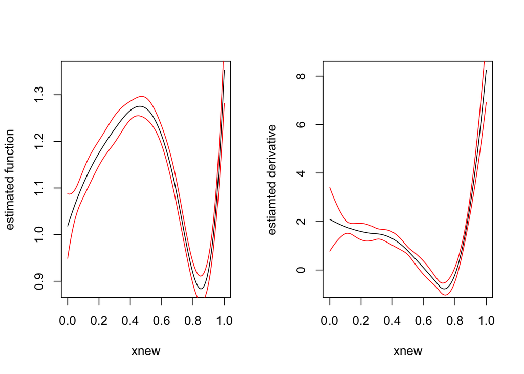

```r
# Regression function plot
xnew = seq(0, 1, 0.01)
x1new = xnew; x2new = xnew^2; x3new = xnew^3
x4new = (xnew-0.3)^3*(xnew>0.3)
x5new = (xnew-0.5)^3*(xnew>0.5)
x6new = (xnew-0.7)^3*(xnew>0.7)

pred =  predict(fm, list(x1 = x1new, x2 = x2new, x3 = x3new,
                           x4 = x4new, x5 = x5new, x6 = x6new), interval='confidence')

par(mfrow=c(1,2))
plot(xnew, pred[,1], type='l', ylab='estimated function')
lines(xnew, pred[,2], col='red')
lines(xnew, pred[,3], col='red')

# Derivative Plot
xnew = seq(0, 1, 0.01)
x1new = xnew*0+1; x2new = 2*xnew^1; x3new = 3*xnew^2
x4new = 3*(xnew-0.3)^2*(xnew>0.3)
x5new = 3*(xnew-0.5)^2*(xnew>0.5)
x6new = 3*(xnew-0.7)^2*(xnew>0.7)

pred =  predict(fm, list(x1 = x1new, x2 = x2new, x3 = x3new,
                           x4 = x4new, x5 = x5new, x6 = x6new), interval='confidence')

plot(xnew, pred[,1], type='l', ylab='estiamted derivative')
lines(xnew, pred[,2], col='red')
lines(xnew, pred[,3], col='red')
```

## Question 2: Cubic Spline Regression - Dangers of Extrapolation

We set knots at every $20$ values of $x$. Note however that the knots are not equally spaced.

```r
xy <- read.table('dataT04b.dat')
y = xy[,1]; x = xy[,2]

# Insert knots every 20 values of x
S = sort(x)
(K = S[c(20, 40, 60, 80)]) # knot values
```

```
## [1]  2.1383  4.7588 10.5910 23.5706
```

```r
x1 = x; x2 = x^2; x3 = x^3
x4 = (x-K[1])^3*(x>K[1])
x5 = (x-K[2])^3*(x>K[2])
x6 = (x-K[3])^3*(x>K[3])
x7 = (x-K[4])^3*(x>K[4])

fm = lm(y~x1+x2+x3+x4+x5+x6+x7)
summary(fm)
```

```
##
## Call:
## lm(formula = y ~ x1 + x2 + x3 + x4 + x5 + x6 + x7)
##
## Residuals:
##     Min      1Q  Median      3Q     Max
## -1.3349 -0.3565 -0.0278  0.3188  2.4569
##
## Coefficients:
##               Estimate Std. Error t value Pr(>|t|)
## (Intercept) -7.2274892  4.5260702  -1.597  0.11369
## x1          13.9527829  7.2490672   1.925  0.05731 .
## x2          -7.2416087  3.6553763  -1.981  0.05054 .
## x3           1.2150209  0.5922531   2.052  0.04303 *
## x4          -1.2986354  0.6129375  -2.119  0.03678 *
## x5           0.0884980  0.0280891   3.151  0.00219 **
## x6          -0.0040906  0.0024763  -1.652  0.10192
## x7          -0.0010960  0.0003789  -2.893  0.00476 **
## ---
## Signif. codes:  0 '***' 0.001 '**' 0.01 '*' 0.05 '.' 0.1 ' ' 1
##
## Residual standard error: 0.7334 on 93 degrees of freedom
## Multiple R-squared:  0.8825, Adjusted R-squared:  0.8736
## F-statistic: 99.77 on 7 and 93 DF,  p-value: < 2.2e-16
```

Generating plot of estimated function:

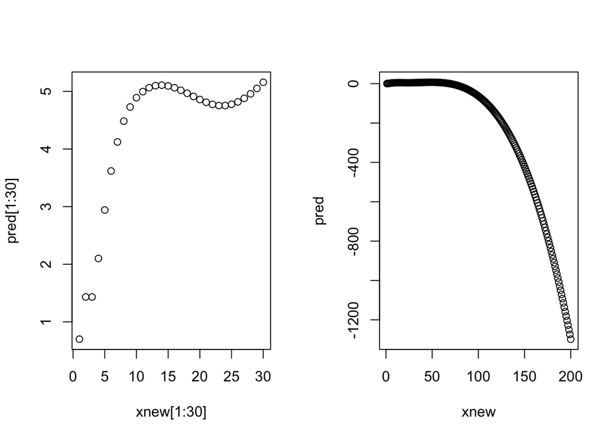

```r
xnew = 1:200
x1new = xnew; x2new = xnew^2; x3new = xnew^3
x4new = (xnew-K[1])^3*(xnew>K[1])
x5new = (xnew-K[2])^3*(xnew>K[2])
x6new = (xnew-K[3])^3*(xnew>K[3])
x7new = (xnew-K[4])^3*(xnew>K[4])

pred = predict(fm, list(x1=x1new, x2=x2new, x3=x3new,
                          x4=x4new, x5=x5new, x6=x6new, x7=x7new))

par(mfrow = c(1,2))
plot(xnew[1:30], pred[1:30])
plot(xnew, pred)
```

Observe that the fitting outside the observed region is not reliable.

## Question 4: Partially Linear Additive Model

Observe that $\beta_1$ is significant by the t-test, with $t = 63.054$ and corresponding p-value $< 2e-16$ (significant for any sig level $\alpha$).

```r
# Loading dataset
xy = read.table('dataT04C.dat')
y = xy[,1]; x1 = xy[,2]; x2 = xy[,3] # first feature z = x1, second feature x = x2
x2a = x2; x2b = x2^2; x2c = x2^3;
x2d = (x2-0.3)^3*(x2>0.3) # fitting model at two knots
x2e = (x2-0.6)^3*(x2>0.6) # (0.3, 0.6)

out0 = lm(y~x1+x2a+x2b+x2c+x2d+x2e)
summary(out0)
```

```
##
## Call:
## lm(formula = y ~ x1 + x2a + x2b + x2c + x2d + x2e)
##
## Residuals:
##      Min       1Q   Median       3Q      Max
## -0.70761 -0.19552 -0.01152  0.19210  0.76036
##
## Coefficients:
##              Estimate Std. Error t value Pr(>|t|)
## (Intercept)  -0.02483    0.14227  -0.175 0.861709
## x1            5.19010    0.08231  63.054  < 2e-16 ***
## x2a           3.22084    2.67363   1.205 0.230321
## x2b          13.66848   13.13364   1.041 0.299760
## x2c         -47.04995   18.27437  -2.575 0.011050 *
## x2d          97.38370   24.53313   3.969 0.000114 ***
## x2e         -51.02325   15.54037  -3.283 0.001290 **
## ---
## Signif. codes:  0 '***' 0.001 '**' 0.01 '*' 0.05 '.' 0.1 ' ' 1
##
## Residual standard error: 0.279 on 143 degrees of freedom
## Multiple R-squared:  0.9738, Adjusted R-squared:  0.9727
## F-statistic: 884.5 on 6 and 143 DF,  p-value: < 2.2e-16
```

Next, testing significance of the non-linear component:

```r
out1 = lm(y~x1)
# Testing H0: g(.) = 0
anova(out1, out0)
```

```
## Analysis of Variance Table
##
## Model 1: y ~ x1
## Model 2: y ~ x1 + x2a + x2b + x2c + x2d + x2e
##   Res.Df    RSS Df Sum of Sq   F    Pr(>F)
## 1    148 84.302
## 2    143 11.131  5    73.171 188 < 2.2e-16 ***
## ---
## Signif. codes:  0 '***' 0.001 '**' 0.01 '*' 0.05 '.' 0.1 ' ' 1
```

From the significant F-test, we reject the null and conclude that $g(x)$ is significant at level $\alpha = 0.05$.